# Web Cache

Jun Tan 26370084

Internet search engines, such as Google, Bing, and Ask, keep copies of Web pages so that when you make a query, they can quickly search their stored pages and return their findings to you. These saved pages are called a Web cache. Of course, if the page has changed since the last time it was stored then the search engine serves stale pages. In order to keep the cache fresh, Web pages need to be visited regularly and the cache updated with any changed pages. How often do Web pages change? How often should the sites be visited to keep the cache fresh? In this article, we consider these questions. This case study is based on the statistical analyses described in [1-3].

# This Study

To help answer these questions, we study the behavior of 1,000 Web pages. Each of these pages was visited every hour for 30 days. The page was compared to the previous visit, and if it had changed, the cache was updated and time of the visit was recorded.

For example, consider the hypothetical set of 8 hourly visits to a Web page shown in the figure below. The top horizontal line shows when the page actually changed and the bottom line shows when a change was detected by a visit to the site. We see that the page changed 7 times, as denoted by the 7 dots that appear along the top line at the times when the page changed. Notice that the page changed twice between hours 3 and 4, but when we visit the page, we observe only that the page has changed between these times, not that it has changed twice. Likewise, the page changed 3 times between hours 4 and 5, and all we can ascertain is that the page changed one or more times between these two visits. This means that in our 8 visits, we observed the page had changed on 4 visits. The data recorded for this page would be the visits on which it changed, i.e., 1, 2, 4, 5.

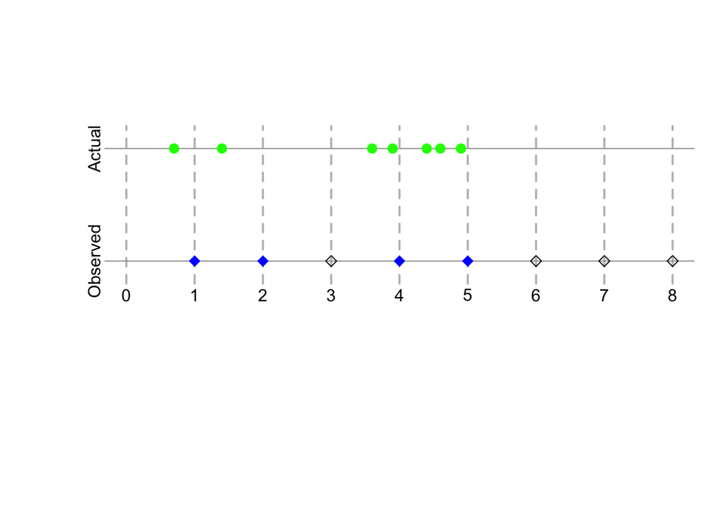

This simple example demonstrates three important features of our data:

- We do not observe the actual time of a change to a Web page, only the time interval in which it changed.
- We do not observe all of the changes. If a page changes on two or more occasions between visits, then we only know that at least one change occurred.
- If we think of a Web page as a record or observation, then our records do not form a typical rectangular shape with a fixed set of columns corresponding to specific variables. For example, the record for our hypothetical Web page contains the values 1, 2, 4, 5 and the record for another Web page may contain only two values such as 2, 7. This situation arises with, e.g., medical records where patients have a varying number of visits to a clinic.

The notion of non-rectangular data impacts how the data are organized and how we write code to analyze the data.

We consider the question of how to estimate a Web page’s rate of change after we have the opportunity to explore the data from the study.